# Project: Estimating Risk of Heart Failure

Suraj Joshi

May 19, 2016

### Title: Estimating Risk of Heart Failure - Data Simulation

### Reference:

Kannel WB, D’Agostino RB, Silbershatz H, Belanger AJ, Wilson PWF, Levy D. Profile for estimating risk of heart failure. Archives of Internal Medicine. 1999;159(11):1197–1204. doi:10.1001/archinte.159.11.1197. http://archinte.jamanetwork.com/article.aspx?articleid=485049. Accessed May 19, 2016.

### Background:

Heart Failure is the disease of elderly. It is present in 1% of the population between 50-59 yrs old and 10% between 80-89 yrs old.

Heart failure is a progressive, often terminal stage of cardiac disease that, when symptomatic, curtails survival like many types of cancer. In Framingham Study subjects with overt congestive heart failure, the median survival rate was only 1.7 years for men and 3.2 years for women.

Heart fails dues to multiple causes. Most common are Coronary artery disease and Myocardial infraction. Others causes can be Hypertension, Myocarditis, Aoric stenosis, Mitral stenosis, tricuspid stenosis, regurgitation of mitral or aortic valve, Constrictive pericarditis, Restrictive Cardiomyopathy, Left ventricular hypertrophy, fibrosis, cardiac tamponade, arrythmias, congenital heart diseases etc. Some non cardiac diseases also contribute to the worsening of heart diseases like diabetes mellitus and pulmonary hypertension.

The study considered some conditions which can be easily assessed in the outpatient setting and come up with a risk score for having heart disease in 4 yrs time. Some of the factors considered were:  
-Age  
-Left Ventricular Hypertrophy (LVH) using EKG  
-Cardiomegaly (ratio >.5)  
-Heart Rate (HR)  
-Systolic BP (SBP)  
-Diabetes Mellitus (DM)  
-Valvular Heart Disease (VHD) presence of murmur > 3/6 and  
-Congenital Heart Disease (CHD)

The study on which the referenced paper is based on is the Framingham Study which is a prospective, epidemiological, population-based study designed to investigate the prevalence, incidence, and determinants of cardiovascular disease.

### Objective:

-To come up with the heart failure risk score and predict the occurance of heart failue in a patient using history and examination in the clinic and simple investigative tools like EKG and Chest X-ray?

### Methodology:

It is a known fact that heart failure increase by age. Similarly it’s contributing factors like hypertension, diabetes mellitus, valvular heart disease, left ventricular hypertrophy etc also increase by age. Here, most features are linearly and positively correlated with age. And each feature also is positively correlated with risk score.

Attempts were made to make the data mimic population prevalence of the conditions and definitely more effort will improve the outcome.  
A sample of 500 observations were generated mimicking the study. The study provided mean values but not the standard deviations.  
-Age was generated using random normal distribution with mean age of 63 and standard deviation of 10 yrs.  
-LVH, Cardiomegaly, Diabetes Mellitus, VHD and CHD were generated using random uniform distribution value and logistic equation.  
-Heart rate and systolic blood pressure were measured using random normal distribution using mean of 75.8 and 149.5 respectively from the study.  
-Few outliers were added to age, heart rate and systolic blood pressure.

The study developed a point system to calculate the risk but to make the calculation simpler I decided to use the weightage multipliers system to mimic the data.

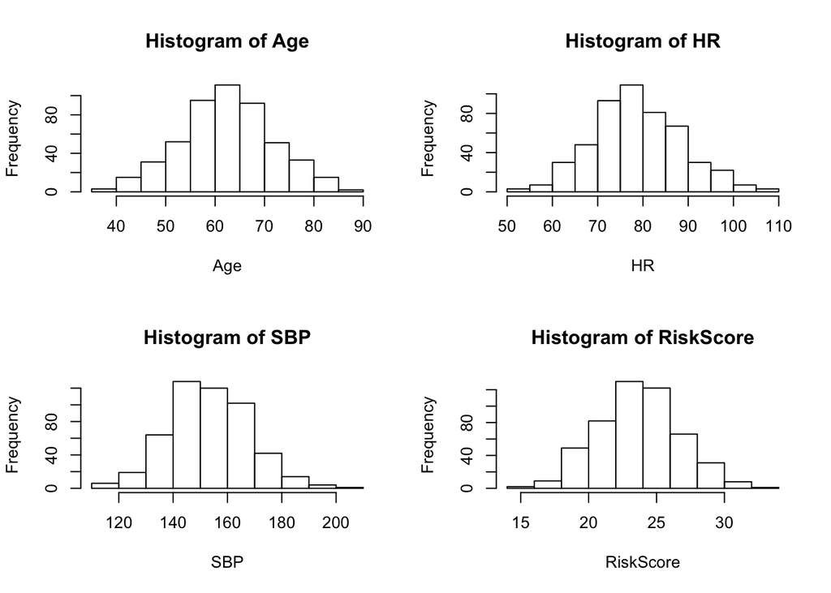

```r
logistic <- function(t) 1 / (1 + exp(-t))

N<- 500
generateDataset <- function (N) {
  set.seed(1000)
  Age <- round(rnorm(N, 63, 10))
  par(mfrow=c(2,2))
  hist(Age, 10)

  LVH <- runif(N)< .25*logistic((Age-60)/10) # # Left Ventricular Hypertrophy on EKG # boolean 0 = none 1 = present
  (sum(LVH==TRUE)/N)*100 #  ~ 15 % in population to find the prevalence in the given age group

  Cardiomegaly <- runif(N)< .08*logistic((Age-60)/10) # Xray # boolean 0 or 1
  (sum(Cardiomegaly==TRUE)/N)*100

  HR <- round(rnorm(N, 75.8,10)+Age*.05) # heart rate # high if > 120 bpm numerical
  hist(HR)

  SBP<- round(rnorm(N,149.5, 10)-70+(Age+Age*.1+5)) # systolic blood pressure >140 mmHg numerical
  hist(SBP)

  DM <- runif(N)< .17*logistic((Age-60)/10) # diabetes mellitus or in insulin or oral hypoglycemics boolean 0 or
  (sum(DM==TRUE)/N)*100

  VHD <- runif(N)< .2*logistic((Age-45)/10)  # valvular heart disease # boolean  0 or 1
  # Epidemiology of acquired valvular heart disease. http://www.ncbi.nlm.nih.gov/pubmed/24986049
  (sum(VHD==TRUE)/N)*100

  CHD <- runif(N)< .06*logistic((Age-60)/10) # congenital heart disease # boolean 0 or 1
  (sum(CHD==TRUE)/N)*100

  RiskScore <- 10*(Age*.025+LVH*.01+Cardiomegaly*.0001+HR*.0002+SBP*.005+.07*DM+VHD*.01+CHD*.03)
  hist(RiskScore)

  # Outliers
  a = sample(1:500, 10)
  Age[a] <- ifelse(Age[a] > 75, Age[a]+10, Age[a])
  HR[1] <- max(HR) + 20
  SBP[1] <- max(SBP) + 20

  data.frame(Age,LVH, Cardiomegaly, HR, SBP, DM, VHD, CHD, RiskScore)
}
dataset <- generateDataset(500)
```

### Analysis:

Data Exploration: To confirm we have the assumed data distribution, mean and reasonable standard deviation, we plot a histogram of the quantitative measures.

Summary of the dataset

```r
summary(dataset)
```

```
##       Age           LVH          Cardiomegaly          HR
##  Min.   :36.00   Mode :logical   Mode :logical   Min.   : 52.0
##  1st Qu.:57.00   FALSE:421       FALSE:472       1st Qu.: 72.0
##  Median :63.00   TRUE :79        TRUE :28        Median : 79.0
##  Mean   :63.12   NA's :0         NA's :0         Mean   : 79.2
##  3rd Qu.:69.00                                   3rd Qu.: 86.0
##  Max.   :90.00                                   Max.   :127.0
##       SBP            DM             VHD             CHD
##  Min.   :116.0   Mode :logical   Mode :logical   Mode :logical
##  1st Qu.:144.0   FALSE:455       FALSE:432       FALSE:489
##  Median :153.0   TRUE :45        TRUE :68        TRUE :11
##  Mean   :153.8   NA's :0         NA's :0         NA's :0
##  3rd Qu.:164.0
##  Max.   :224.0
##    RiskScore
##  Min.   :14.94
##  1st Qu.:21.76
##  Median :23.68
##  Mean   :23.71
##  3rd Qu.:25.59
##  Max.   :32.07
```

[Distribution] (https://github.com/spa380/DataSimulation616/blob/master/data_dist.png)

The summary of the dataset and the plots confirm the distributions of the data we aimed for.

```r
cor(dataset)
```

```
##                     Age          LVH Cardiomegaly          HR          SBP
## Age          1.00000000  0.110264822  0.070358033  0.06188687  0.701368184
## LVH          0.11026482  1.000000000 -0.010111865  0.04600923  0.071383388
## Cardiomegaly 0.07035803 -0.010111865  1.000000000 -0.03014032  0.004826697
## HR           0.06188687  0.046009225 -0.030140318  1.00000000  0.118921511
## SBP          0.70136818  0.071383388  0.004826697  0.11892151  1.000000000
## DM           0.09779513 -0.002107639  0.014589798 -0.01812901  0.062569762
## VHD          0.09228188  0.004095048 -0.020503831 -0.02070869  0.105467978
## CHD          0.03839583  0.047176313 -0.036530022 -0.07966611 -0.004777387
## RiskScore    0.98007829  0.122129234  0.058895548  0.07228586  0.807609624
##                        DM          VHD          CHD  RiskScore
## Age           0.097795130  0.092281878  0.038395825 0.98007829
## LVH          -0.002107639  0.004095048  0.047176313 0.12212923
## Cardiomegaly  0.014589798 -0.020503831 -0.036530022 0.05889555
## HR           -0.018129011 -0.020708686 -0.079666105 0.07228586
## SBP           0.062569762  0.105467978 -0.004777387 0.80760962
## DM            1.000000000 -0.002446487 -0.047167458 0.16271545
## VHD          -0.002446487  1.000000000 -0.019728978 0.11399993
## CHD          -0.047167458 -0.019728978  1.000000000 0.04185314
## RiskScore     0.162715453  0.113999932  0.041853135 1.00000000
```

We would also want to verify the linearity between the age and few features related to age eg. SBP and diabetes.

```r
par(mfrow=c(1,2))
fit.AgeSBP <- lm(SBP~Age, data = dataset)
summary(fit.AgeSBP)
```

```
##
## Call:
## lm(formula = SBP ~ Age, data = dataset)
##
## Residuals:
##     Min      1Q  Median      3Q     Max
## -32.135  -6.847  -0.520   6.769  74.750
##
## Coefficients:
##             Estimate Std. Error t value Pr(>|t|)
## (Intercept)  83.4376     3.2424   25.73   <2e-16 ***
## Age           1.1155     0.0508   21.96   <2e-16 ***
## ---
## Signif. codes:  0 '***' 0.001 '**' 0.01 '*' 0.05 '.' 0.1 ' ' 1
##
## Residual standard error: 10.77 on 498 degrees of freedom
## Multiple R-squared:  0.4919, Adjusted R-squared:  0.4909
## F-statistic: 482.2 on 1 and 498 DF,  p-value: < 2.2e-16
```

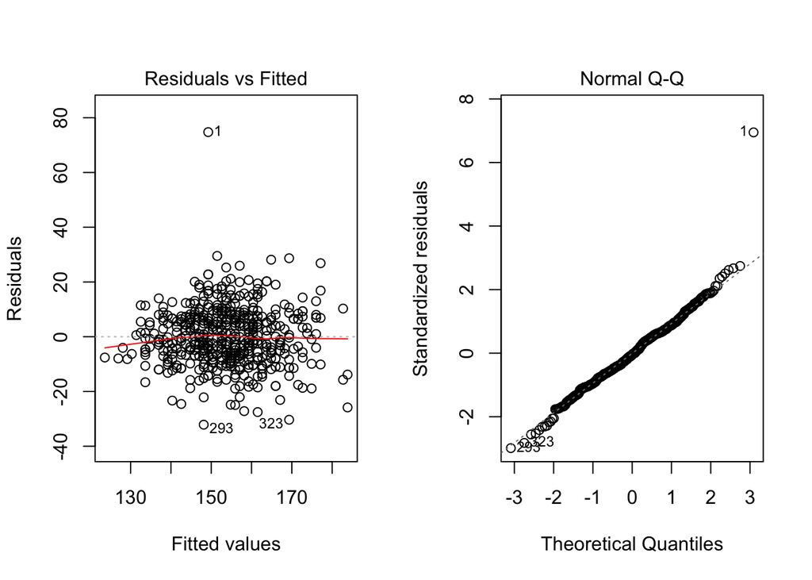

```r
plot(fit.AgeSBP,1)
plot(fit.AgeSBP,2)
```

We see in the figure below that the data is normally distributed with some outliers.

[Distribution] (https://github.com/spa380/DataSimulation616/blob/master/Age_SBP.png)

We can see the positive co-linearity between Age and SBP in the figure below :

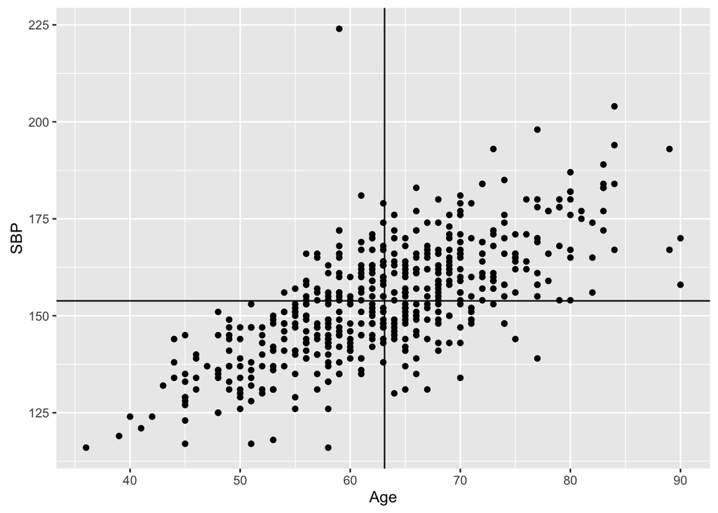

```r
require(ggplot2)
ggplot(dataset, aes(x=Age, y = SBP))+
  geom_point()+
  geom_vline(xintercept = mean(dataset$Age))+
  geom_hline(yintercept = mean(dataset$SBP))
```

[Distribution] (https://github.com/spa380/DataSimulation616/blob/master/AgeSBP_Linearity.png)

We can also see from the figure below that about 60% of the diabetics are above the mean age of sample of 63yrs.

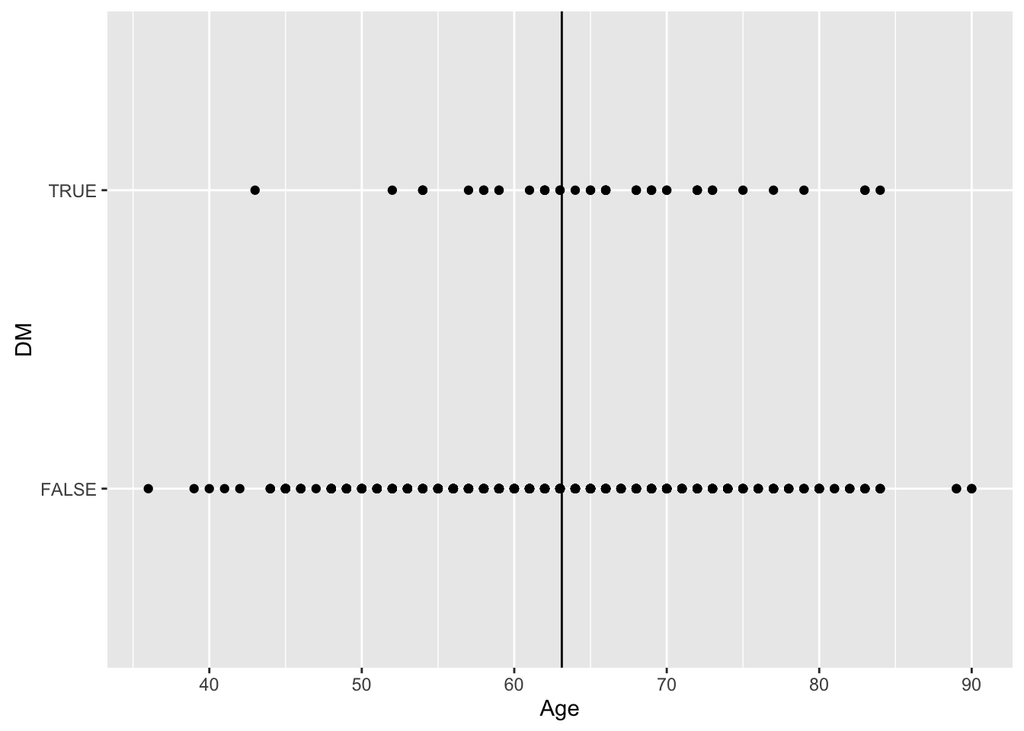

```r
ggplot(dataset, aes(x=Age, y = DM))+
  geom_point()+
  geom_vline(xintercept = mean(dataset$Age))+
  geom_hline(yintercept = mean(dataset$DM))
```

[Distribution] (https://github.com/spa380/DataSimulation616/blob/master/DiabetesAge.png)

Now, looking at age and risk score, we find a positive correlation between them. [Distribution] (https://github.com/spa380/DataSimulation616/blob/master/Age_vs_RiskScore.png)

The plot below shows that the diabetic patients have higher risk scores.

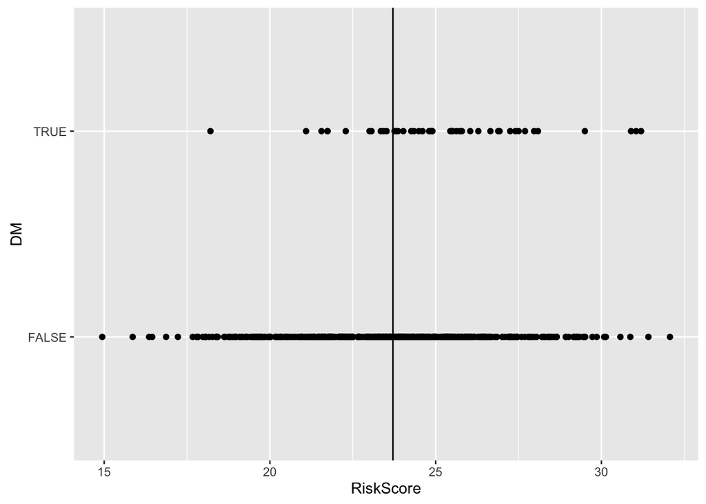

```r
ggplot(dataset, aes(y=DM, x = RiskScore))+
  geom_point()+geom_vline(xintercept = mean(dataset$RiskScore))
```

[Distribution] (https://github.com/spa380/DataSimulation616/blob/master/DM_vs_RiskScore.png)

Validating with t-test to find out if mean of the risk scores is significantly different in diabetics.

t.test(RiskScore~DM, data = dataset, var.equal = FALSE)

[output not shown]

```r
par(mfrow=c(1,2))
fit.RiskScore <- lm(RiskScore~., data = dataset)
summary(fit.RiskScore)
```

```
##
## Call:
## lm(formula = RiskScore ~ ., data = dataset)
##
## Residuals:
##     Min      1Q  Median      3Q     Max
## -3.2963 -0.0211  0.0141  0.0503  0.2121
##
## Coefficients:
##                    Estimate Std. Error t value Pr(>|t|)
## (Intercept)       0.6569112  0.1233011   5.328 1.52e-07 ***
## Age               0.2508809  0.0014964 167.654  < 2e-16 ***
## LVHTRUE           0.1316178  0.0275786   4.772 2.40e-06 ***
## CardiomegalyTRUE  0.0148475  0.0436658   0.340    0.734
## HR               -0.0010847  0.0010156  -1.068    0.286
## SBP               0.0467640  0.0009374  49.887  < 2e-16 ***
## DMTRUE            0.7249696  0.0350958  20.657  < 2e-16 ***
## VHDTRUE           0.1311477  0.0293139   4.474 9.55e-06 ***
## CHDTRUE           0.2981661  0.0685983   4.347 1.68e-05 ***
## ---
## Signif. codes:  0 '***' 0.001 '**' 0.01 '*' 0.05 '.' 0.1 ' ' 1
##
## Residual standard error: 0.2231 on 491 degrees of freedom
## Multiple R-squared:  0.9944, Adjusted R-squared:  0.9943
## F-statistic: 1.097e+04 on 8 and 491 DF,  p-value: < 2.2e-16
```

Summary of fit.RiskScore

Call:  
lm(formula = RiskScore ~ ., data = dataset)

### Conclusion

-We can successfully simulate data which will help us in calculating the risk of heart failure with reasonable accuracy.

-Even with method different from the point system, satisfactory level of data can be simulated for risk assessment.